# Final Project

Team 7

## Preparation

```r
# Load packages used in this session of R
library(broom)
library(ggpubr)
library(tidyverse)
library(tidyr)
library(knitr)
library(dplyr)
library(readr)

# As needed, set path to folder where data is located.
opts_knit$set(root.dir = "C:/Users/yusuk/OneDrive/Documents/OPIM601-100/FinalProject")
#capitalbike <- read_csv("Capital Bike Sharing data by hour.csv", skip = 1)
capitalbike <- read_csv("Capital Bike Sharing data by hour.csv")
capitalbike <- capitalbike[,1:17]
view(capitalbike)
```

#### 1) What is the trend in overall bike demand over the months of the year?

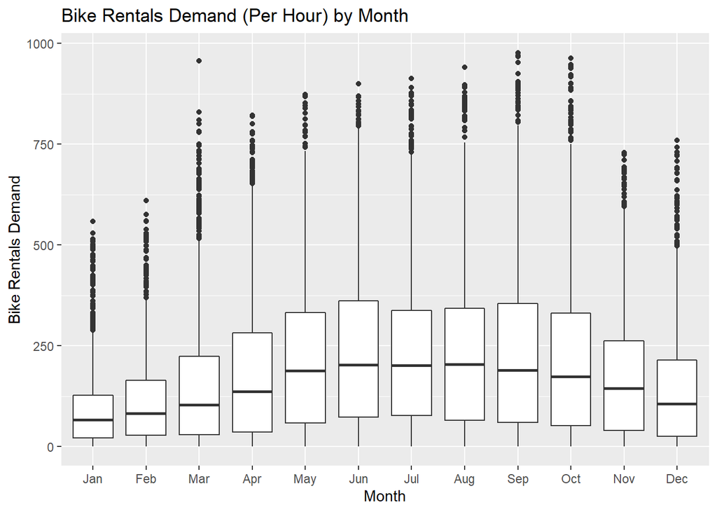

```r
#Plot boxplot per month looking at hourly data points
capitalbike %>%
  ggplot(aes(x = as.factor(mnth), y = cnt)) +
  geom_boxplot() +
  scale_x_discrete(labels = lubridate::month(1:12, label = T)) +
  labs(title = "Bike Rentals Demand (Per Hour) by Month", x = "Month", y = "Bike Rentals Demand")
```

#### 2) The data science group at Capital bike share hypothesize that a. There must be high demand during office timings. Early morning and late evening can have different trends (cyclist) and low demand from 10:00pm to 4:00am. Do you agree?

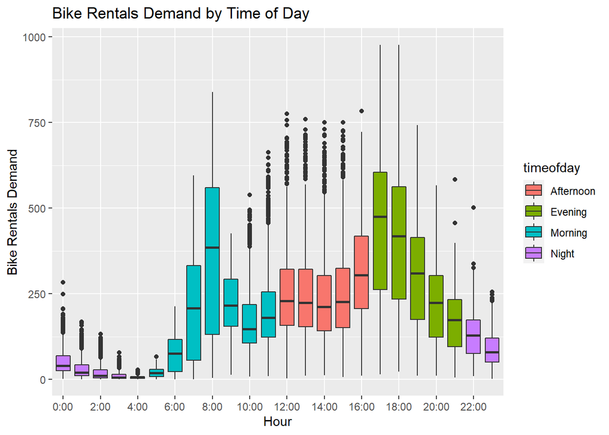

```r
#Plot boxplot per month looking at hourly data points
capitalbike %>%
  mutate(timeofday = case_when(hr < 5 ~ "Night",
                               hr < 12 ~ "Morning",
                               hr < 17 ~ "Afternoon",
                               hr < 22 ~ "Evening",
                               TRUE ~ "Night")) %>%
  ggplot(aes(x = as.factor(hr), y = cnt, fill = timeofday)) +
  geom_boxplot() +
  scale_x_discrete(breaks = seq(0,22,by=2),labels = paste(seq(0,22,by=2), ":00",sep = "")) +
  labs(title = "Bike Rentals Demand by Time of Day", x = "Hour", y = "Bike Rentals Demand")
```

### B. Registered users demand more bike on weekdays compared to the weekend or holiday. Do you agree?

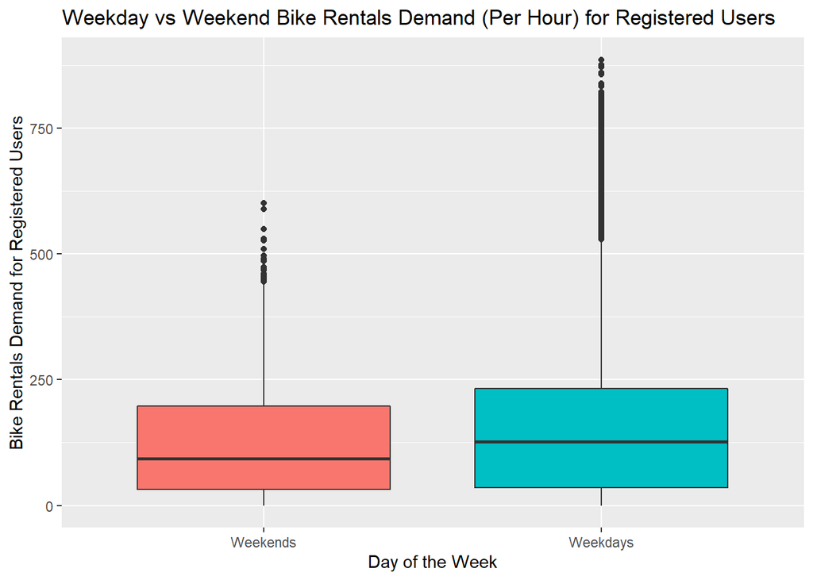

```r
capitalbike %>%
  ggplot(aes(x = as.factor(workingday), y = Registered, fill = as.factor(workingday))) +
  geom_boxplot(show.legend = F) +
  labs(title = "Weekday vs Weekend Bike Rentals Demand (Per Hour) for Registered Users",
       x = "Day of the Week",
       y = "Bike Rentals Demand for Registered Users") +
  scale_x_discrete(labels = c("Weekends", "Weekdays"))
```

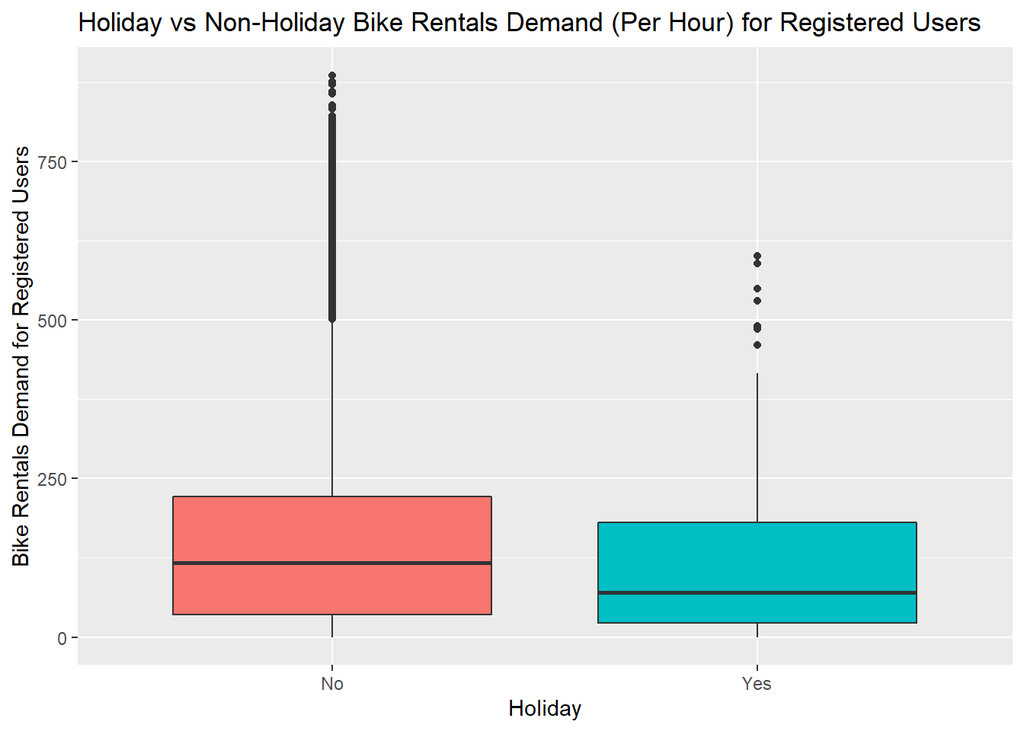

```r
capitalbike %>%
  ggplot(aes(x = as.factor(holiday), y = Registered, fill = as.factor(holiday))) +
  geom_boxplot(show.legend = F) +
  labs(title = "Holiday vs Non-Holiday Bike Rentals Demand (Per Hour) for Registered Users",
       x = "Holiday",
       y = "Bike Rentals Demand for Registered Users") +
  scale_x_discrete(labels = c("No", "Yes"))
```

### C. Casual users demand more bike on weekdays compared to the weekend or holiday. Do you agree?

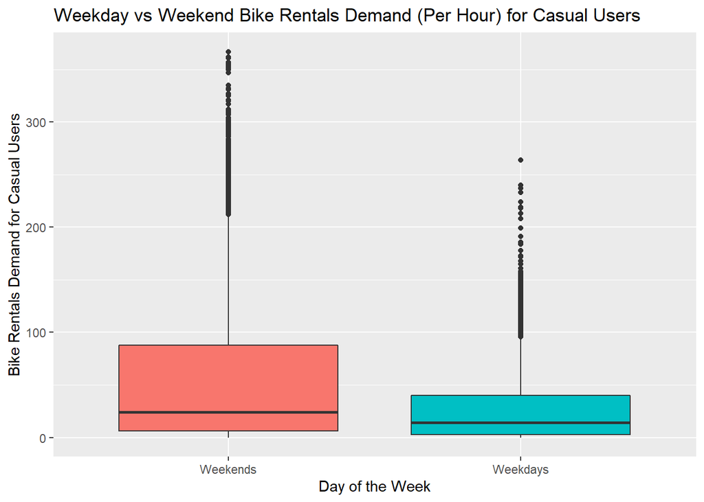

```r
capitalbike %>%
  ggplot(aes(x = as.factor(workingday), y = Casual, fill = as.factor(workingday))) +
  geom_boxplot(show.legend = F) +
  labs(title = "Weekday vs Weekend Bike Rentals Demand (Per Hour) for Casual Users",
       x = "Day of the Week",
       y = "Bike Rentals Demand for Casual Users") +
  scale_x_discrete(labels = c("Weekends", "Weekdays"))
```

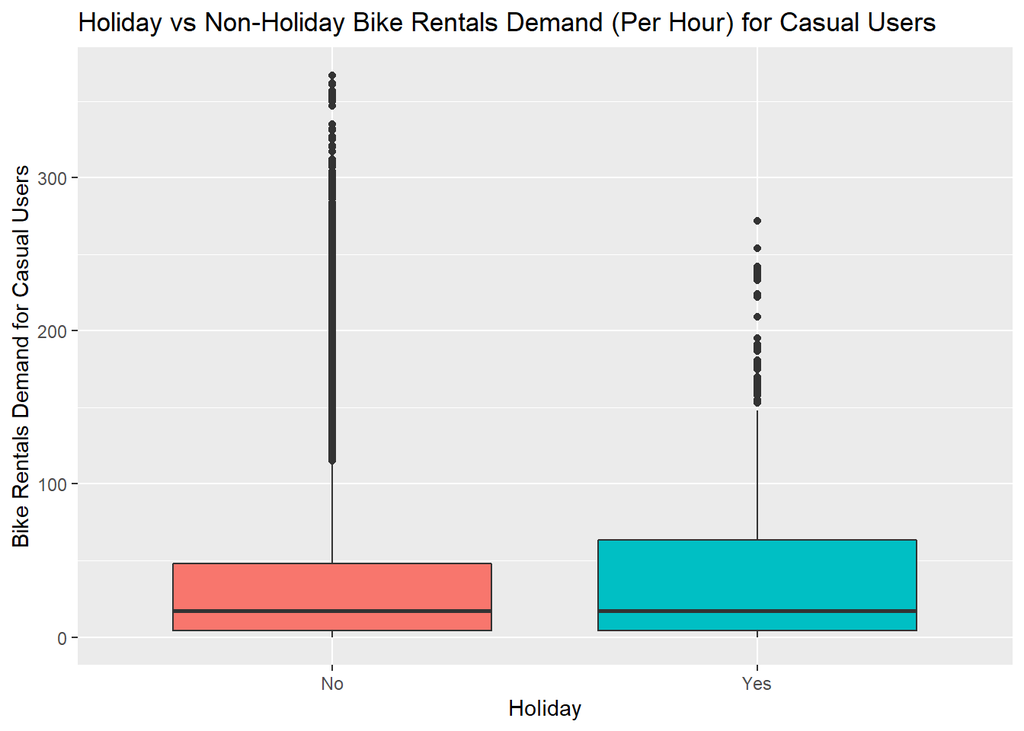

```r
capitalbike %>%
  ggplot(aes(x = as.factor(holiday), y = Casual, fill = as.factor(holiday))) +
  geom_boxplot(show.legend = F) +
  labs(title = "Holiday vs Non-Holiday Bike Rentals Demand (Per Hour) for Casual Users",
       x = "Holiday",
       y = "Bike Rentals Demand for Casual Users") +
  scale_x_discrete(labels = c("No", "Yes"))
```

### 3) Is there any relationship between season and bike rental? Create a visualization displaying the relationship.

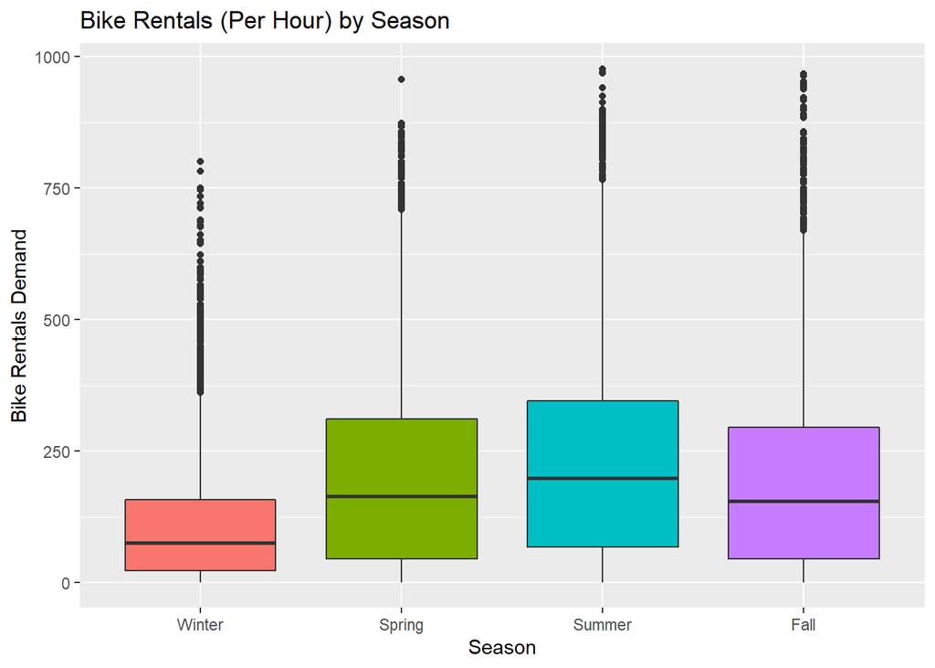

```r
ggplot(capitalbike, aes(x = as.factor(season), y = cnt, fill = as.factor(season))) +
  geom_boxplot(show.legend = F) +
  labs(title = "Bike Rentals (Per Hour) by Season",
       x = "Season",
       y = "Bike Rentals Demand") +
  scale_x_discrete(labels = c("Winter", "Spring", "Summer", "Fall"))
```

### 4) What type of relationship do you see between weather and bike rental? Is the relationship the same for registered vs. casual users?

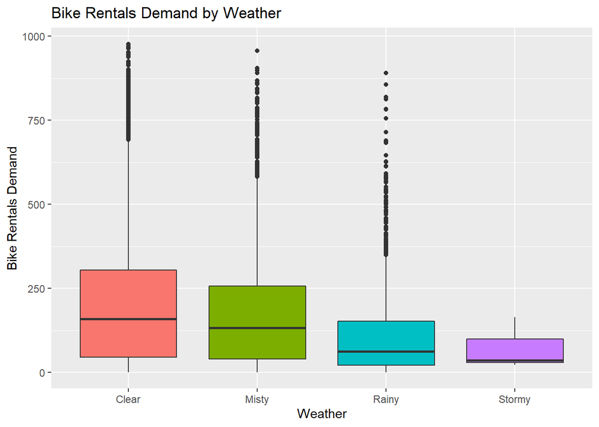

```r
ggplot(capitalbike, aes(x = as.factor(weathersit), y = cnt, fill = as.factor(weathersit))) +
  geom_boxplot(show.legend = F) +
  labs(title = "Bike Rentals Demand by Weather",
       x = "Weather",
       y = "Bike Rentals Demand") +
  scale_x_discrete(labels = c("Clear", "Misty", "Rainy", "Stormy"))
```

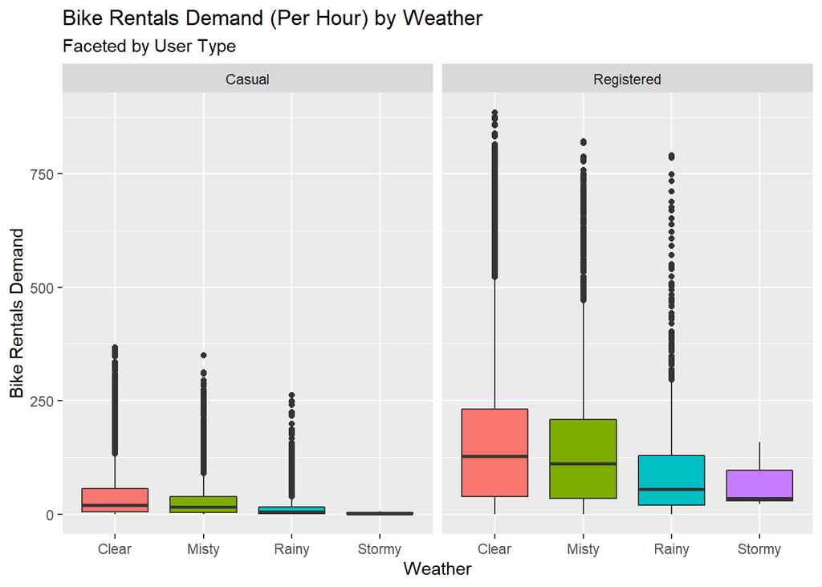

```r
capitalbike %>%
  pivot_longer(c("Registered", "Casual")) %>%
  ggplot(aes(x = as.factor(weathersit), y = value, fill = as.factor(weathersit))) +
  geom_boxplot(show.legend = F) +
  labs(title = "Bike Rentals Demand (Per Hour) by Weather",
       subtitle = "Faceted by User Type",
       x = "Weather",
       y = "Bike Rentals Demand") +
  scale_x_discrete(labels = c("Clear", "Misty", "Rainy", "Stormy")) +
  facet_wrap(~name)
```

#### 5) Fit a linear model predicting the total bike rental demand from daily temperature. What kind of insights can you generate? (make sure to write the linear model and interpret it in the context of the data)

```r
#Group by hourly
capitalbike_dtemp <- capitalbike %>% group_by(dteday) %>% summarize(cnt_daily1 =sum(cnt, na.rm = T),
                                                                    meantemp1 =mean(temp, na.rm = T))
capitalbike_dtemp
```

```
## # A tibble: 731 x 3
##    dteday    cnt_daily1 meantemp1
##    <chr>          <dbl>     <dbl>
##  1 1/1/2011         985     0.344
##  2 1/1/2012        2294     0.37
##  3 1/10/2011       1321     0.151
##  4 1/10/2012       3598     0.309
##  5 1/11/2011       1263     0.169
##  6 1/11/2012       2177     0.274
##  7 1/12/2011       1162     0.173
##  8 1/12/2012       4097     0.382
##  9 1/13/2011       1406     0.165
## 10 1/13/2012       3214     0.274
## # ... with 721 more rows
```

```r
#summary(capitalbike_dtemp)
#cor.test(capitalbike_dtemp$cnt_daily1, capitalbike_dtemp$meantemp1)


temp_lm_plot = lm(capitalbike_dtemp$cnt_daily1 ~ capitalbike_dtemp$meantemp1, data = capitalbike_dtemp)
summary(temp_lm_plot)
```

```
##
## Call:
## lm(formula = capitalbike_dtemp$cnt_daily1 ~ capitalbike_dtemp$meantemp1,
##     data = capitalbike_dtemp)
##
## Residuals:
##     Min      1Q  Median      3Q     Max
## -4615.3 -1134.9  -104.4  1044.3  3737.8
##
## Coefficients:
##                             Estimate Std. Error t value Pr(>|t|)
## (Intercept)                   1214.6      161.2   7.537 1.43e-13 ***
## capitalbike_dtemp$meantemp1   6640.7      305.2  21.759  < 2e-16 ***
## ---
## Signif. codes:  0 '***' 0.001 '**' 0.01 '*' 0.05 '.' 0.1 ' ' 1
##
## Residual standard error: 1509 on 729 degrees of freedom
## Multiple R-squared:  0.3937, Adjusted R-squared:  0.3929
## F-statistic: 473.5 on 1 and 729 DF,  p-value: < 2.2e-16
```

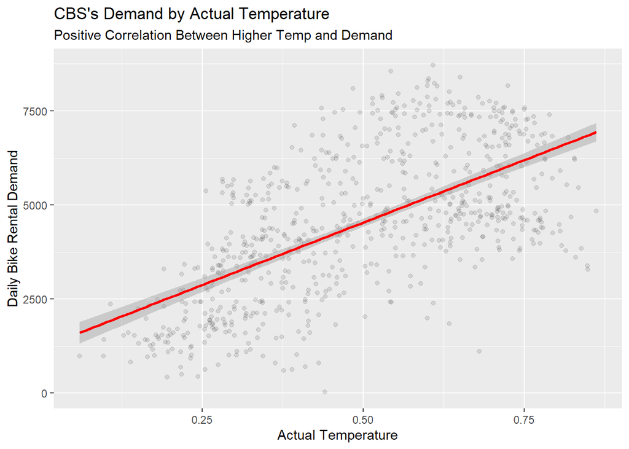

```r
(temp_lm_plot = ggplot(capitalbike_dtemp, aes(x = meantemp1, y = cnt_daily1)) +
  geom_jitter(alpha = 0.10, color = "Black") +
  stat_smooth(method = "lm", col = "red") +
  labs(x = "Actual Temperature",
  y = "Daily Bike Rental Demand",
  title = "CBS's Demand by Actual Temperature",
  subtitle = "Positive Correlation Between Higher Temp and Demand") +
  theme(legend.position = "none"))
```

#### 6) Fit another linear model predicting total daily bike rentals from daily feeling temperature. Write the linear model, interpret the slope, etc. Is the temperature or feeling temperature a better predictor of bike rentals?

```r
capitalbike_ftemp <- capitalbike %>% group_by(dteday) %>% summarize(cnt_daily2 =sum(cnt, na.rm = T),
                                                                    meantemp2 =mean(atemp, na.rm = T))
capitalbike_ftemp
```

```
## # A tibble: 731 x 3
##    dteday    cnt_daily2 meantemp2
##    <chr>          <dbl>     <dbl>
##  1 1/1/2011         985     0.364
##  2 1/1/2012        2294     0.376
##  3 1/10/2011       1321     0.151
##  4 1/10/2012       3598     0.319
##  5 1/11/2011       1263     0.191
##  6 1/11/2012       2177     0.283
##  7 1/12/2011       1162     0.160
##  8 1/12/2012       4097     0.382
##  9 1/13/2011       1406     0.151
## 10 1/13/2012       3214     0.249
## # ... with 721 more rows
```

```r
summary(capitalbike_ftemp)
```

```
##     dteday            cnt_daily2     meantemp2
##  Length:731         Min.   :  22   Min.   :0.07907
##  Class :character   1st Qu.:3152   1st Qu.:0.33784
##  Mode  :character   Median :4548   Median :0.48673
##                     Mean   :4504   Mean   :0.47435
##                     3rd Qu.:5956   3rd Qu.:0.60860
##                     Max.   :8714   Max.   :0.84090
```

```r
cor.test(capitalbike_ftemp$cnt_daily2, capitalbike_ftemp$meantemp2)
```

```
##
##  Pearson's product-moment correlation
##
## data:  capitalbike_ftemp$cnt_daily2 and capitalbike_ftemp$meantemp2
## t = 21.965, df = 729, p-value < 2.2e-16
## alternative hypothesis: true correlation is not equal to 0
## 95 percent confidence interval:
##  0.5853376 0.6727917
## sample estimates:
##       cor
## 0.6310656
```

```r
feeltemp_lm = lm(capitalbike_ftemp$cnt_daily2 ~ capitalbike_ftemp$meantemp2, data = capitalbike_ftemp)
summary(feeltemp_lm)
```

```
##
## Call:
## lm(formula = capitalbike_ftemp$cnt_daily2 ~ capitalbike_ftemp$meantemp2,
##     data = capitalbike_ftemp)
##
## Residuals:
##     Min      1Q  Median      3Q     Max
## -4598.7 -1091.5   -91.8  1072.0  4383.7
##
## Coefficients:
##                             Estimate Std. Error t value Pr(>|t|)
## (Intercept)                    945.8      171.3   5.522 4.67e-08 ***
## capitalbike_ftemp$meantemp2   7501.8      341.5  21.965  < 2e-16 ***
## ---
## Signif. codes:  0 '***' 0.001 '**' 0.01 '*' 0.05 '.' 0.1 ' ' 1
##
## Residual standard error: 1504 on 729 degrees of freedom
## Multiple R-squared:  0.3982, Adjusted R-squared:  0.3974
## F-statistic: 482.5 on 1 and 729 DF,  p-value: < 2.2e-16
```

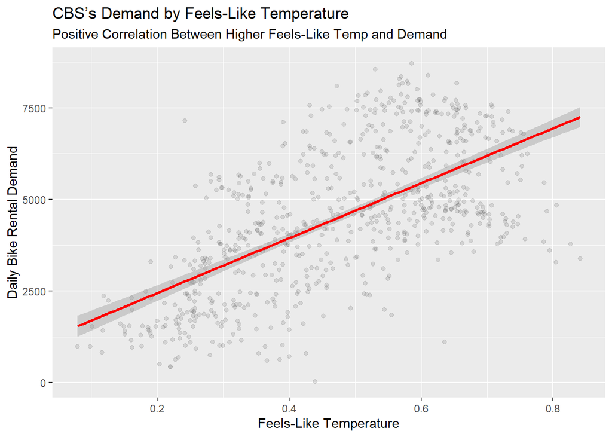

```r
(feeltemp_lm = ggplot(capitalbike_ftemp, aes(x = meantemp2, y = cnt_daily2)) +
    geom_jitter(alpha = 0.10, color = "Black") +
    stat_smooth(method = "lm", col = "red") +
    labs(x = "Feels-Like Temperature",
         y = "Daily Bike Rental Demand",
         title = "CBS’s Demand by Feels-Like Temperature",
         subtitle = "Positive Correlation Between Higher Feels-Like Temp and Demand") +
    theme(legend.position = "none"))
```

#### 7) What is your overall recommendation about the demand for bike rentals for the Capital Bike Share management? Share your insights with the company based on your analysis.